# Assignment 4

Exploratory Data Analysis

Dean D’souza

2016-07-09

## Objective

The objective of this assignment is to familiarize your self with the process, specifically the visual process of Exploratory Data Analysis (EDA). I have assigned several readings to support this work and layout an overall procedure. You should read **Zuur et al.** prior to completing this work.

## Directions

Using any data set in `R`, for instance the `titatic` data set found within the `library(datasets)` package as your analysis data. Conduct an EDA on the data set of your choice. Your analysis should follow the “key steps” discussed in **Zuur et al.** and in our lecture discussion.

You analysis should be completed within an **Rmarkdown** document. The assignment should show data import, and any data cleanup that you conduct. The document should show the steps in your EDA including:

- $\geq$ 5 statistical graphics.
- Each graphic should include plot titles, proper axis labels, and legend information, if neccesary.
- Along with each plot include a short statement indicating what you learned from that plot. (This could be anything from verifying a `sort()` or `filter()` call to a `mosaic()` plot showing sample size variability).

The final document should be converted using the `knitr` package to an `.html` file and submitted via Moodle for evaluation. Remember to properly name your file as: `YourName_ANLY512-50_SU2016.html`.

## Your EDA

For my EDA I chose the data set “iris” (Edgar Anderson’s Iris Data)which contatins the following covariates:  
+ Sepal.Length (numeric) + Sepal.Width (numeric) + Petal.Length (numeric) + Petal.Width (numeric) + Species (categorical)

```r
library(datasets)
library(ggplot2)
data("iris")
head(iris)
```

```
##   Sepal.Length Sepal.Width Petal.Length Petal.Width Species
## 1          5.1         3.5          1.4         0.2  setosa
## 2          4.9         3.0          1.4         0.2  setosa
## 3          4.7         3.2          1.3         0.2  setosa
## 4          4.6         3.1          1.5         0.2  setosa
## 5          5.0         3.6          1.4         0.2  setosa
## 6          5.4         3.9          1.7         0.4  setosa
```

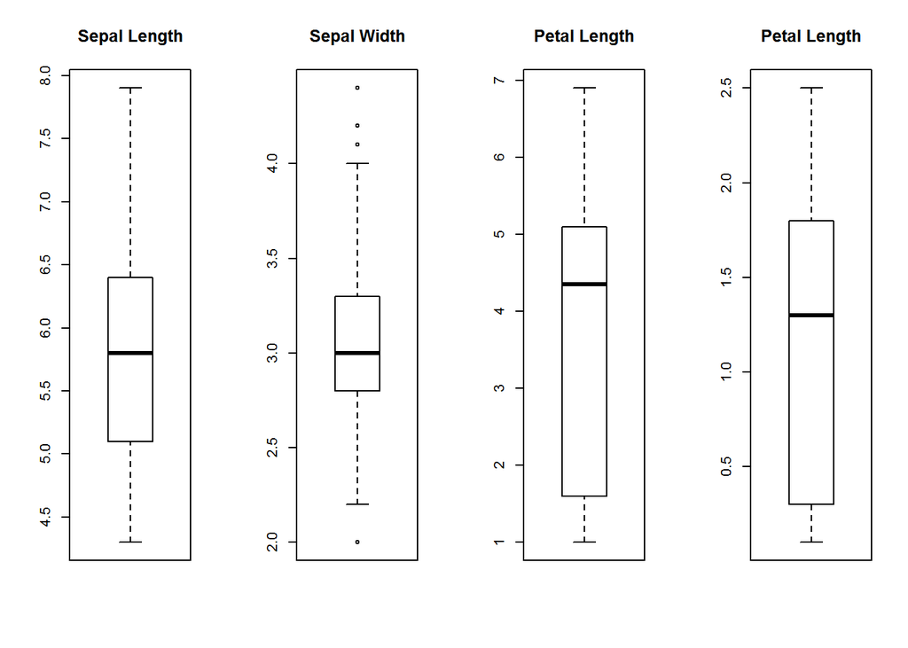

```r
# Checking for outliers
par(mfrow=c(1,4))
boxplot(iris$Sepal.Length, main="Sepal Length")
boxplot(iris$Sepal.Width, main="Sepal Width")
boxplot(iris$Petal.Length, main="Petal Length")
boxplot(iris$Petal.Width, main="Petal Length")
```

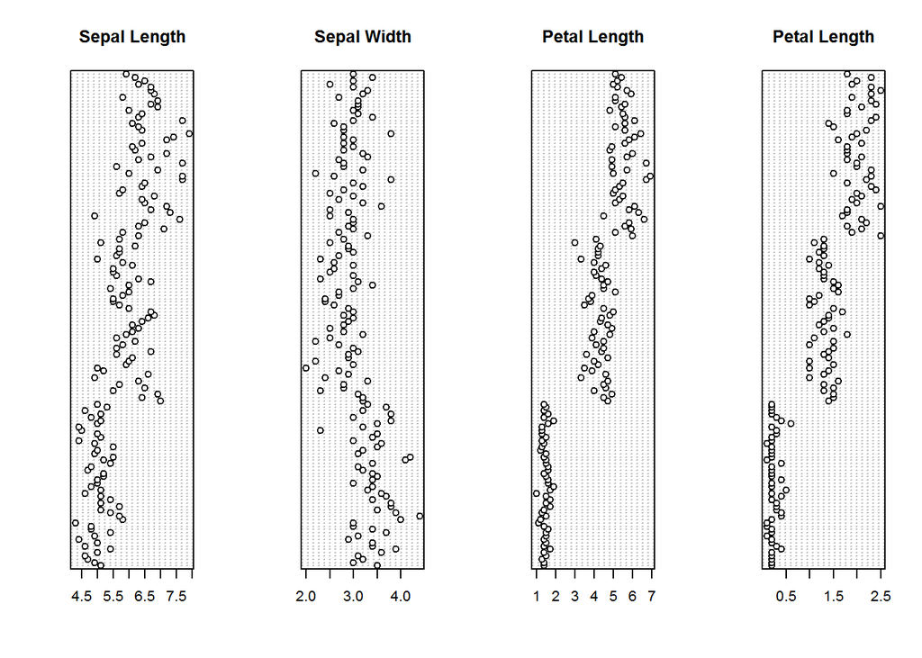

```r
dotchart(iris$Sepal.Length, main="Sepal Length")
dotchart(iris$Sepal.Width, main="Sepal Width")
dotchart(iris$Petal.Length, main="Petal Length")
dotchart(iris$Petal.Width, main="Petal Length")
```

Here we can see that the sepal width variable has a few outliers on the higher end and an outlier on the lower end.We can also see through the dotcharts that there is a gap between values. We take a closer look at seapl width over the various levels of the categorical variable Species.

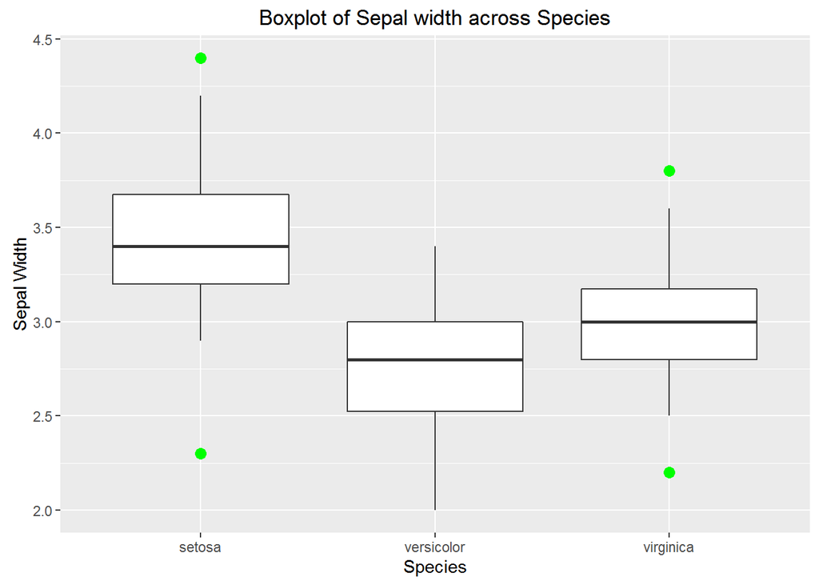

```r
p1<-ggplot(iris, aes(x=Species, y=Sepal.Width))+geom_boxplot(outlier.colour = "green", outlier.size = 3)+ylab("Sepal Width")+ggtitle("Boxplot of Sepal width across Species")
p1
```

The above plot shows that the outliers are mainly for the species of setosa and virginica. These outliers would definitely have an influence on the response variable (in this case sepal width).

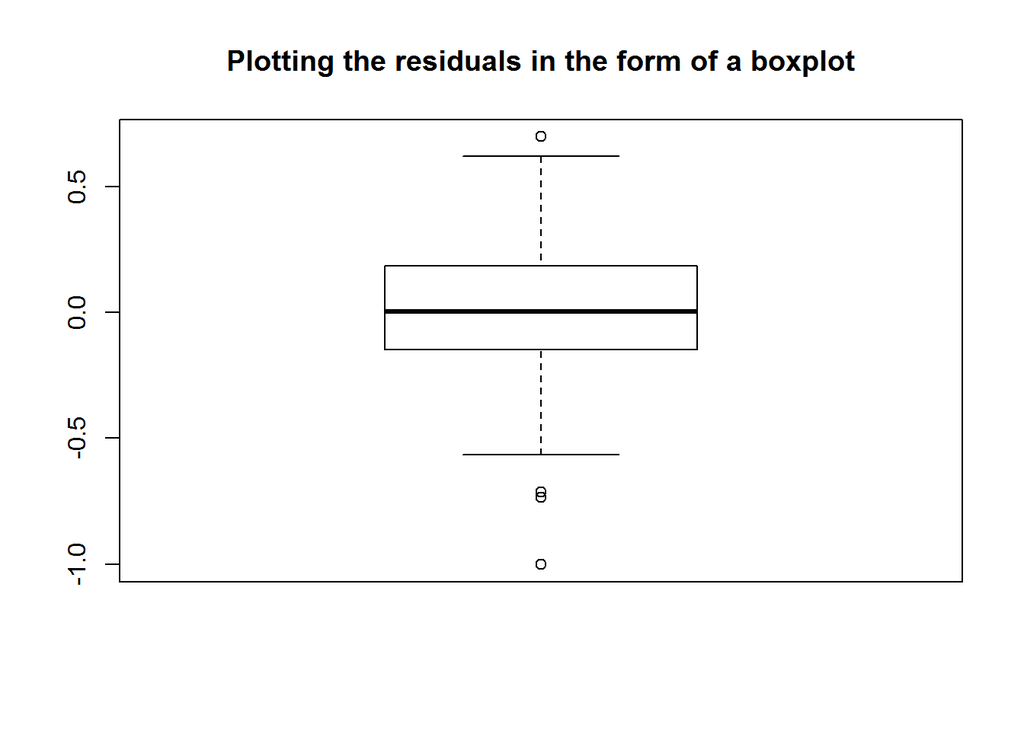

```r
# Checking for homogenity of variance
sw.lm<-lm(Sepal.Width~Sepal.Length+Petal.Length+Petal.Width+Species, data=iris)
sw.res<-resid(sw.lm)
par(mfrow=c(1,1))
boxplot(sw.res, main="Plotting the residuals in the form of a boxplot")
```

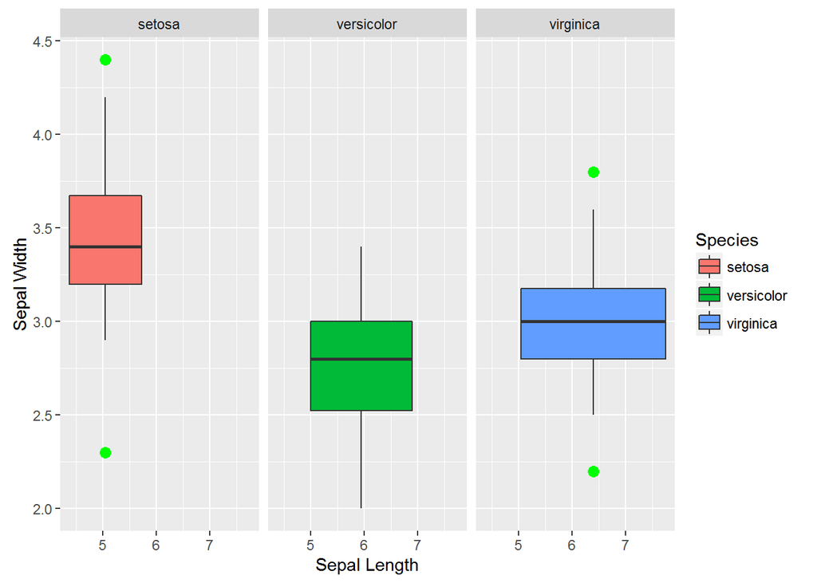

```r
p2<-ggplot(iris, aes(x=Sepal.Length, y=Sepal.Width, fill=Species))+geom_boxplot(outlier.colour = "green", outlier.size = 3)+ylab("Sepal Width")+xlab("Sepal Length")+facet_wrap(~Species, drop = TRUE)
p2
```

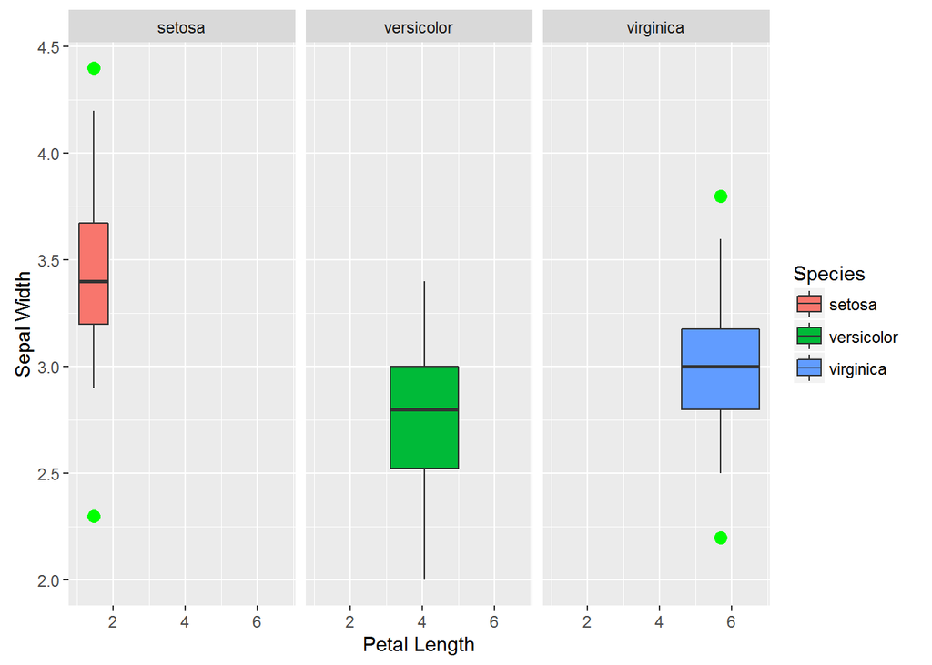

```r
p3<-ggplot(iris, aes(x=Petal.Length, y=Sepal.Width, fill=Species))+geom_boxplot(outlier.colour = "green", outlier.size = 3)+ylab("Sepal Width")+xlab("Petal Length")+facet_wrap(~Species, drop = TRUE)
p3
```

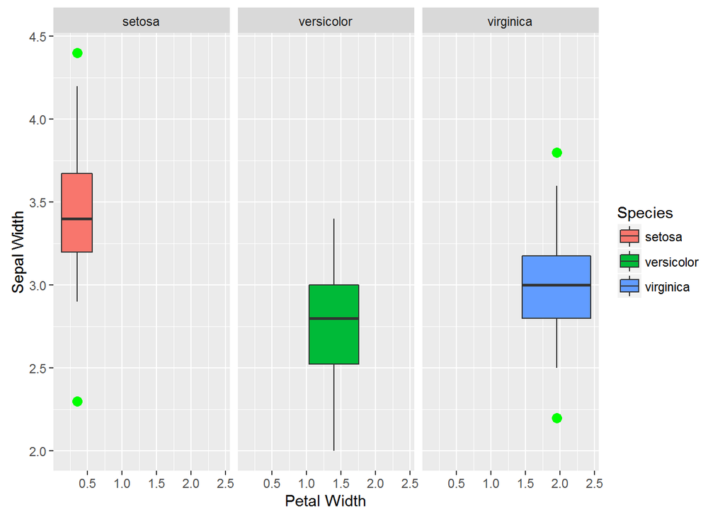

```r
p4<-ggplot(iris, aes(x=Petal.Width, y=Sepal.Width, fill=Species))+geom_boxplot(outlier.colour = "green", outlier.size = 3)+ylab("Sepal Width")+xlab("Petal Width")+facet_wrap(~Species, drop = TRUE)
p4
```

The above boxplot shows us that there are outliers in terms of residuals on the negative end, which could indicate higher variation. Additionally the faceted boxplots shows us the variation of Sepal Width with the covariates across species. For the most part we can see that variance differs only slightly and is simillar among species.

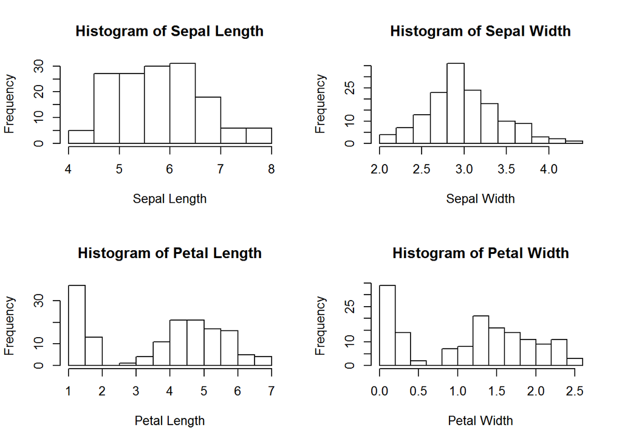

```r
# Checking for normal distribution of data
par(mfrow=c(2,2))
hist(iris$Sepal.Length, main="Histogram of Sepal Length",xlab = "Sepal Length")
hist(iris$Sepal.Width, main="Histogram of Sepal Width",xlab = "Sepal Width")
hist(iris$Petal.Length, main="Histogram of Petal Length",xlab = "Petal Length")
hist(iris$Petal.Width, main="Histogram of Petal Width", xlab = "Petal Width")
```

The above histograms helps us see that while sepal width is normally distributed, and sepal length shows a somewhat normal distribution (with a slight skew), Petal Length and Petal width are clearly not normally distributed and may require the data to be tansformed. We also observe these in the form of frequency plots as follows:

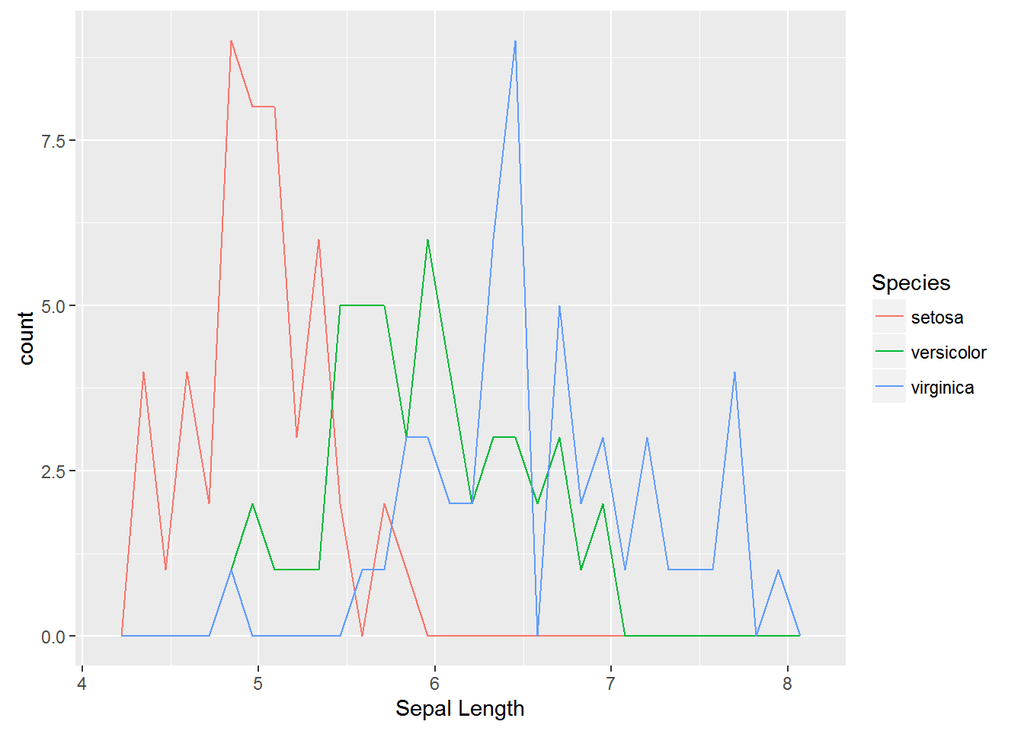

```r
ggplot(iris, aes(x=Sepal.Length, colour = Species))+geom_freqpoly()+xlab("Sepal Length")
```

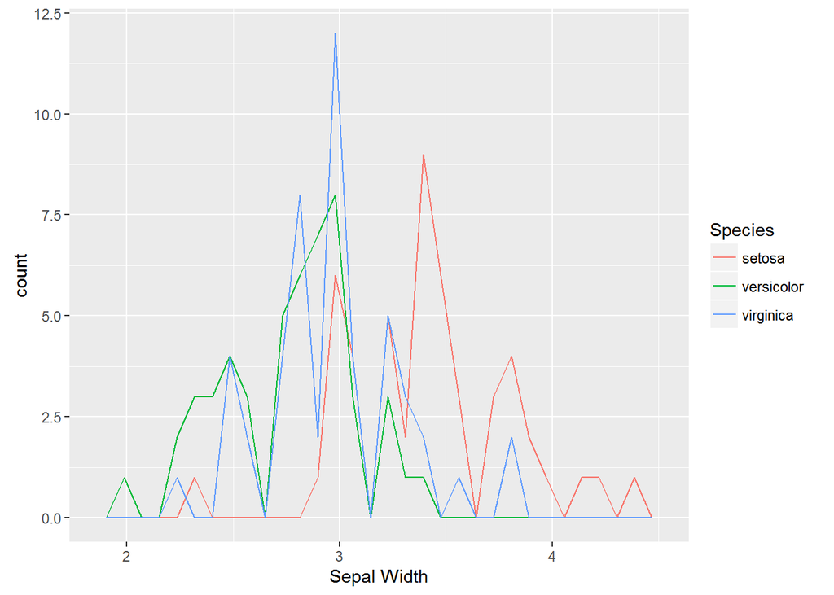

```r
ggplot(iris, aes(x=Sepal.Width, colour = Species))+geom_freqpoly()+xlab("Sepal Width")
```

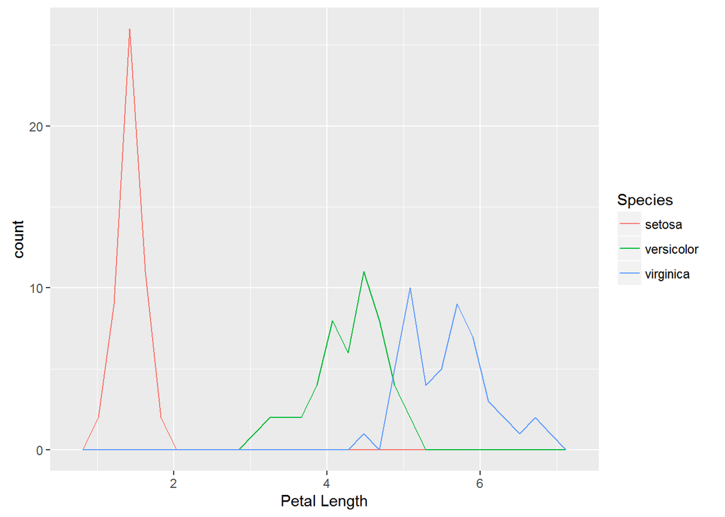

```r
ggplot(iris, aes(x=Petal.Length, colour = Species))+geom_freqpoly()+xlab("Petal Length")
```

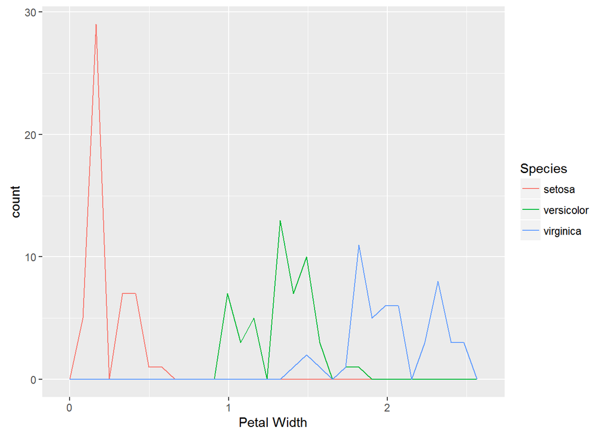

```r
ggplot(iris, aes(x=Petal.Width, colour = Species))+geom_freqpoly()+xlab("Petal Width")
```

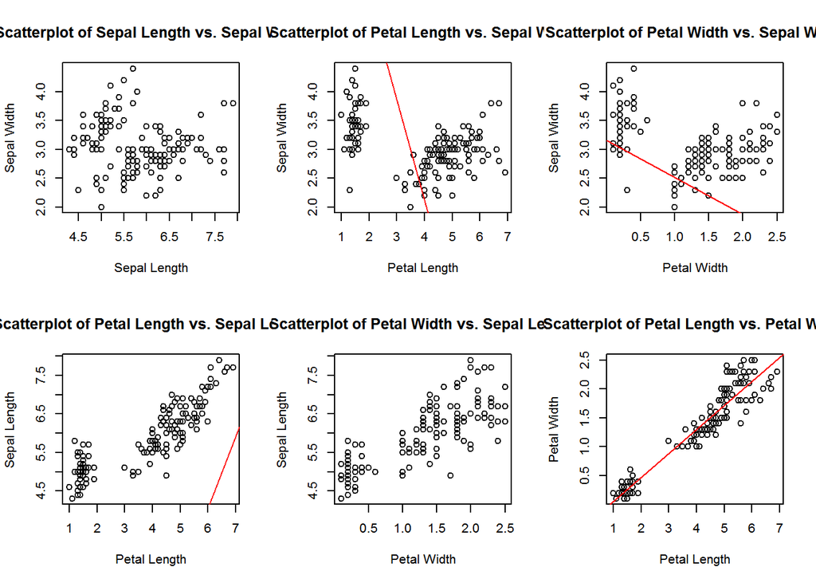

```r
# Checking for collinearity among covariates and relationship between response and explanatory variables:
par(mfrow=c(2,3))

plot(iris$Sepal.Length,iris$Sepal.Width, xlab = "Sepal Length",ylab = "Sepal Width", main = "Scatterplot of Sepal Length vs. Sepal Width")
abline(lm(iris$Sepal.Length~iris$Sepal.Width), col="red")

plot(iris$Petal.Length,iris$Sepal.Width, xlab = "Petal Length",ylab = "Sepal Width", main = "Scatterplot of Petal Length vs. Sepal Width")
abline(lm(iris$Petal.Length~iris$Sepal.Width), col="red")

plot(iris$Petal.Width,iris$Sepal.Width, xlab = "Petal Width",ylab = "Sepal Width", main = "Scatterplot of Petal Width vs. Sepal Width")
abline(lm(iris$Petal.Width~iris$Sepal.Width), col="red")

plot(iris$Petal.Length,iris$Sepal.Length, xlab = "Petal Length",ylab = "Sepal Length", main = "Scatterplot of Petal Length vs. Sepal Length")
abline(lm(iris$Petal.Length~iris$Sepal.Length), col="red")

plot(iris$Petal.Width,iris$Sepal.Length, xlab = "Petal Width",ylab = "Sepal Length", main = "Scatterplot of Petal Width vs. Sepal Length")
abline(lm(iris$Petal.Width~iris$Sepal.Length), col="red")

plot(iris$Petal.Length,iris$Petal.Width, xlab = "Petal Length",ylab = "Petal Width", main = "Scatterplot of Petal Length vs. Petal Width")
abline(lm(iris$Petal.Width~iris$Petal.Length), col="red")
```

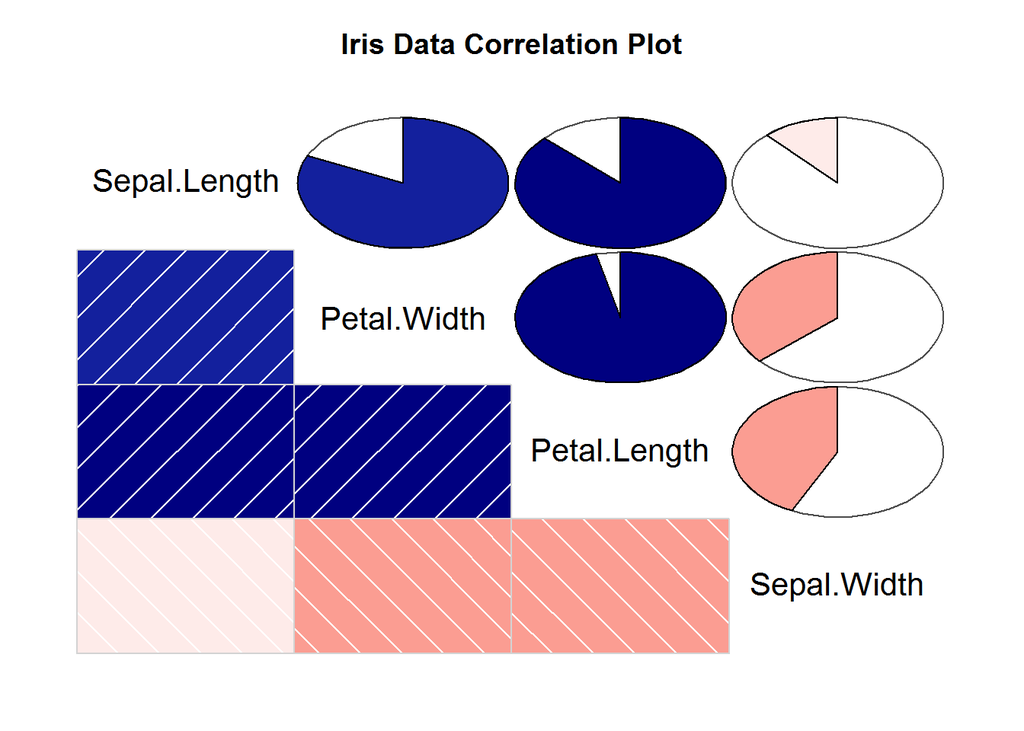

```r
par(mfrow=c(1,1))
library(corrgram)
corrgram(iris, order=TRUE, lower.panel=panel.shade, upper.panel=panel.pie, text.panel=panel.txt, main="Iris Data Correlation Plot")
```

Note: All files can be found on [GitHub](https://github.com/DeanDsouza25/ANLY_512-50_SU2016/tree/master/Assignment_4)